# Titanic Survival Prediction

Loading essential libraries

```r
libs <- c('ggplot2', 'dplyr', 'randomForest', 'rpart', 'rpart.plot', 'car', 'e1071', 'caret')
#install.lib <- libs[!libs %in% installed.packages()]
#install.packages(install.lib)
sapply(libs, require, character = T)
```

```
##      ggplot2        dplyr randomForest        rpart   rpart.plot
##         TRUE         TRUE         TRUE         TRUE         TRUE
##          car        e1071        caret
##         TRUE         TRUE         TRUE
```

### Reading in the data

```r
train.tt <- read.csv("train.csv", stringsAsFactors = F)
test.tt <- read.csv("test.csv", stringsAsFactors = F)

# adding the y column
test.tt$Survived <- NA
```

### Combining the test and training data

```r
full.tt <- rbind(train.tt, test.tt)
```

Checking the structure

```r
str(full.tt)
```

```
## 'data.frame':    1309 obs. of  12 variables:
##  $ PassengerId: int  1 2 3 4 5 6 7 8 9 10 ...
##  $ Survived   : int  0 1 1 1 0 0 0 0 1 1 ...
##  $ Pclass     : int  3 1 3 1 3 3 1 3 3 2 ...
##  $ Name       : chr  "Braund, Mr. Owen Harris" "Cumings, Mrs. John Bradley (Florence Briggs Thayer)" "Heikkinen, Miss. Laina" "Futrelle, Mrs. Jacques Heath (Lily May Peel)" ...
##  $ Sex        : chr  "male" "female" "female" "female" ...
##  $ Age        : num  22 38 26 35 35 NA 54 2 27 14 ...
##  $ SibSp      : int  1 1 0 1 0 0 0 3 0 1 ...
##  $ Parch      : int  0 0 0 0 0 0 0 1 2 0 ...
##  $ Ticket     : chr  "A/5 21171" "PC 17599" "STON/O2. 3101282" "113803" ...
##  $ Fare       : num  7.25 71.28 7.92 53.1 8.05 ...
##  $ Cabin      : chr  "" "C85" "" "C123" ...
##  $ Embarked   : chr  "S" "C" "S" "S" ...
```

### Missing Value Imputation

Number of missing values

```r
apply(full.tt, 2, function(x){sum(is.na(x))})
```

```
## PassengerId    Survived      Pclass        Name         Sex         Age
##           0         418           0           0           0         263
##       SibSp       Parch      Ticket        Fare       Cabin    Embarked
##           0           0           0           1           0           0
```

Empty data points

```r
apply(full.tt, 2, function(x){sum(x == '')})
```

```
## PassengerId    Survived      Pclass        Name         Sex         Age
##           0          NA           0           0           0          NA
##       SibSp       Parch      Ticket        Fare       Cabin    Embarked
##           0           0           0          NA        1014           2
```

- Age has 263 missing values
- Cabin has 1014 missing values
- Embarked has just 2 missing values
- Fare has one missing value

#### Embarked

Replacing embarked with most frequent observations

```r
table(full.tt$Embarked)
```

```
##
##       C   Q   S
##   2 270 123 914
```

Replacing the empty observations

```r
full.tt$Embarked[full.tt$Embarked == ''] <- "S"
table(full.tt$Embarked)
```

```
##
##   C   Q   S
## 270 123 916
```

### Conversion to Factors

Checking to see how many variables can be moved to factors

```r
apply(full.tt, 2, function(x){length(unique(x))})
```

```
## PassengerId    Survived      Pclass        Name         Sex         Age
##        1309           3           3        1307           2          99
##       SibSp       Parch      Ticket        Fare       Cabin    Embarked
##           7           8         929         282         187           3
```

Survived, Sex, Pclass, and Embarked can be converted to factor

```r
cols <- c("Survived", "Sex", "Pclass", "Embarked")
for(i in cols){
  full.tt[,i] <- as.factor(full.tt[,i])
}
```

### Exploratory data Analysis and Feature Engineering

#### rich vs poor

Plotting Pclass and Survived

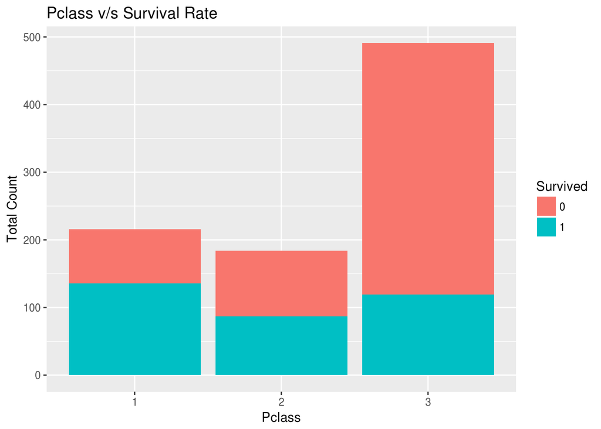

```r
ggplot(full.tt[1:891,], aes(x = Pclass, fill = factor(Survived))) +
geom_bar() +
ggtitle("Pclass v/s Survival Rate")+
xlab("Pclass") +
ylab("Total Count") +
labs(fill = "Survived")
```

First class has better survival rate than others

### Rich and poor Survival rate vs. Sex

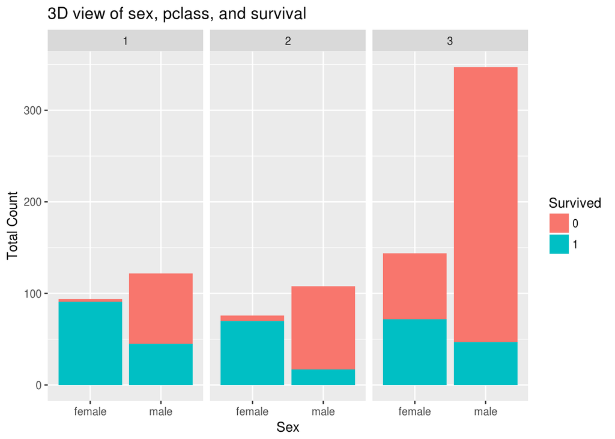

```r
ggplot(full.tt[1:891,], aes(x = Sex, fill = Survived)) +
geom_bar() +
facet_wrap(~Pclass) +
ggtitle("3D view of sex, pclass, and survival") +
xlab("Sex") +
ylab("Total Count") +
labs(fill = "Survived")
```

In all the classes, female survivors are more than the male survivors

### Title

```r
head(full.tt$Name)
```

```
## [1] "Braund, Mr. Owen Harris"
## [2] "Cumings, Mrs. John Bradley (Florence Briggs Thayer)"
## [3] "Heikkinen, Miss. Laina"
## [4] "Futrelle, Mrs. Jacques Heath (Lily May Peel)"
## [5] "Allen, Mr. William Henry"
## [6] "Moran, Mr. James"
```

Extracting title from the names

```r
names <- full.tt$Name
title <- gsub("^.*, (.*?)\\..*$", "\\1", names)
full.tt$title <- title

table(title)
```

```
## title
##         Capt          Col          Don         Dona           Dr
##            1            4            1            1            8
##     Jonkheer         Lady        Major       Master         Miss
##            1            1            2           61          260
##         Mlle          Mme           Mr          Mrs           Ms
##            2            1          757          197            2
##          Rev          Sir the Countess
##            8            1            1
```

- Master, Miss, Mr and Mrs are taking more numbers than anything
- Grouping Others into these bigger categories while checking survival rate and genders
- Also, Creating a feature with too many levels may lead to overfitting, therefore we will combine certain levels while trying to retain reasonable amount of information

Exploring Dona, Lady, Mlle, Mme, Ms

```r
table(full.tt$Sex[full.tt$title %in% c("Dona", "Lady", "Mlle", "Mme", "Ms")])
```

```
##
## female   male
##      7      0
```

Combining levels

```r
full.tt$title[full.tt$title == 'Mlle'] <- 'Miss'
full.tt$title[full.tt$title == 'Ms'] <- 'Miss'
full.tt$title[full.tt$title == 'Mme'] <- 'Mrs'
full.tt$title[full.tt$title == 'Lady'] <- 'Miss'
full.tt$title[full.tt$title == 'Dona'] <- 'Miss'
```

```r
full.tt$title[full.tt$title == 'Capt'] <- 'Officer'
full.tt$title[full.tt$title == 'Col'] <- 'Officer'
full.tt$title[full.tt$title == 'Major'] <- 'Officer'
full.tt$title[full.tt$title == 'Dr'] <- 'Officer'
full.tt$title[full.tt$title == 'Rev'] <- 'Officer'
full.tt$title[full.tt$title == 'Don'] <- 'Officer'
full.tt$title[full.tt$title == 'Sir'] <- 'Officer'
full.tt$title[full.tt$title == 'the Countess'] <- 'Officer'
full.tt$title[full.tt$title == 'Jonkheer'] <- 'Officer'
```

Survival rate for different titles

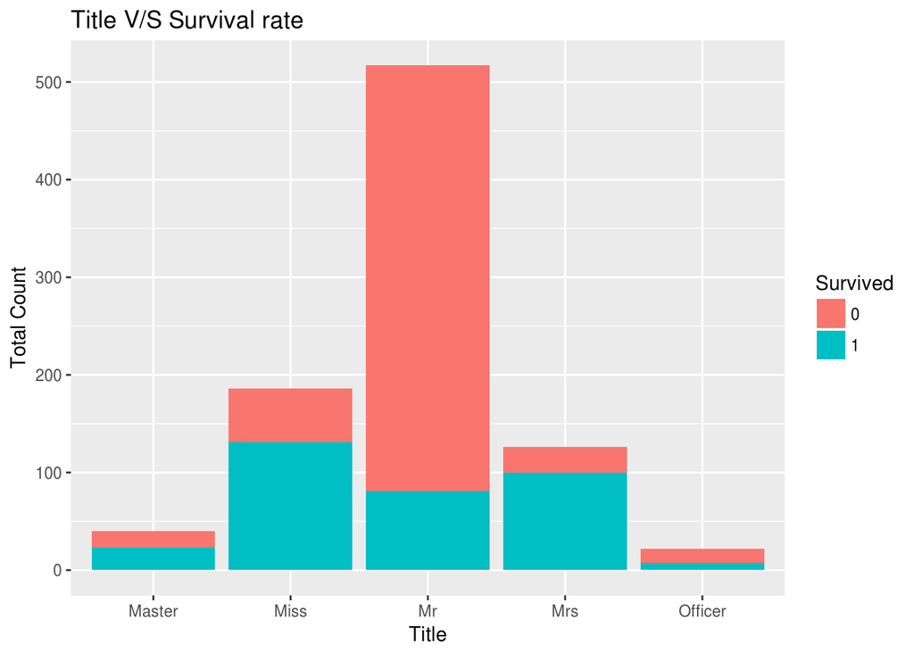

```r
ggplot(full.tt[1:891,], aes(x = title, fill = factor(Survived))) +
  geom_bar() +
  ggtitle("Title V/S Survival rate")+
  xlab("Title") +
  ylab("Total Count") +
  labs(fill = "Survived")
```

* Mr have the least chance of Survival * Miss and Mrs have better survival rate than Officer

Title and Survival rate in different classes

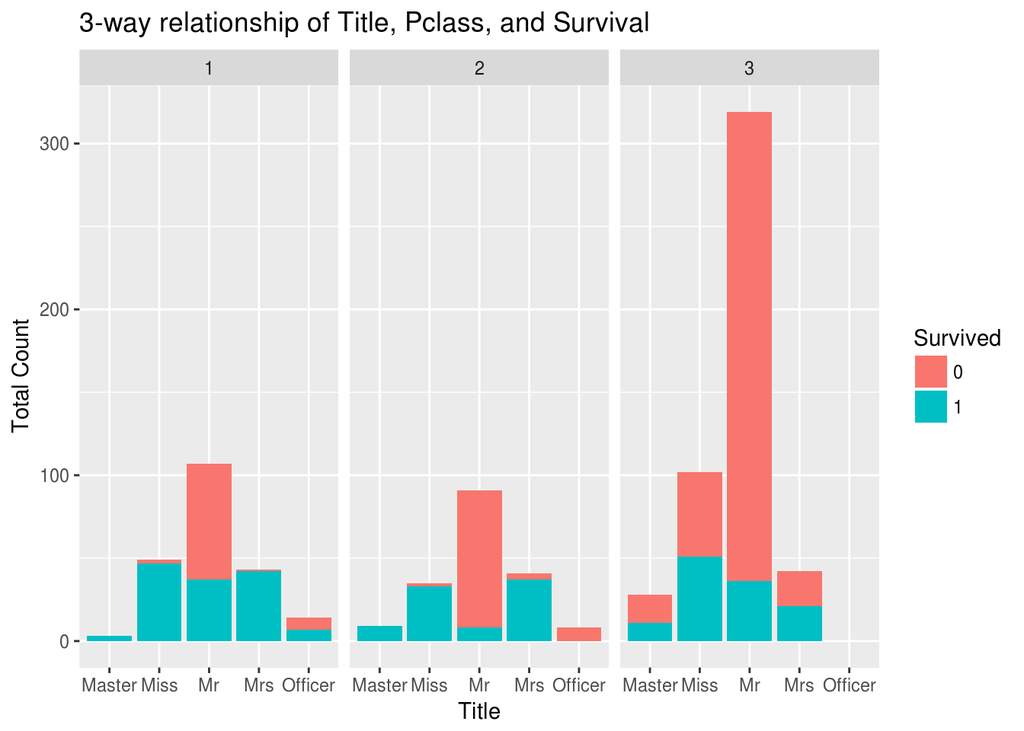

```r
ggplot(full.tt[1:891,], aes(x = title, fill = Survived)) +
  geom_bar() +
  facet_wrap(~Pclass) +
  ggtitle("3-way relationship of Title, Pclass, and Survival") +
  xlab("Title") +
  ylab("Total Count") +
  labs(fill = "Survived")
```

* Master in 1st and 2nd class seems to have 100% survival rate * Mrs and Miss have nearly 90% survival rate in 1st and 2nd class

#### Missing Values in Age

```r
tapply(full.tt$Age, full.tt$title, mean, na.rm = T)
```

```
##    Master      Miss        Mr       Mrs   Officer
##  5.482642 22.026000 32.252151 36.918129 45.307692
```

Since title is mostly dependent upon age, we will be using title since age has 263 missing values.

### Family

Creating a variable called FamilySize using Sibsp and Parch

```r
full.tt$FamilySize <- full.tt$SibSp + full.tt$Parch + 1

full.tt$FamilySized[full.tt$FamilySize == 1] <- 'Single'
full.tt$FamilySized[full.tt$FamilySize < 5 & full.tt$FamilySize >= 2] <- 'Small'
full.tt$FamilySized[full.tt$FamilySize >= 5] <- 'Big'

full.tt$FamilySized <- as.factor(full.tt$FamilySized)
```

Visualizing survival rate for different family size

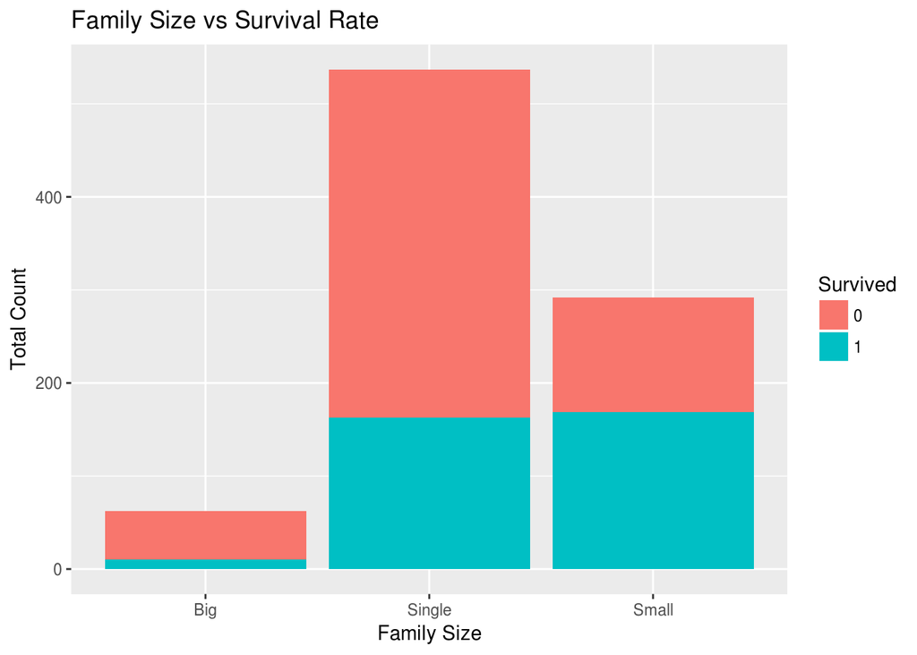

```r
ggplot(full.tt[1:891,], aes(x = FamilySized, fill = factor(Survived))) +
  geom_bar() +
  ggtitle("Family Size vs Survival Rate") +
  xlab("Family Size") +
  ylab("Total Count") +
  labs(fill = "Survived")
```

* Big families have the worst survival rate

Exploring this further by splitting plot further over titles

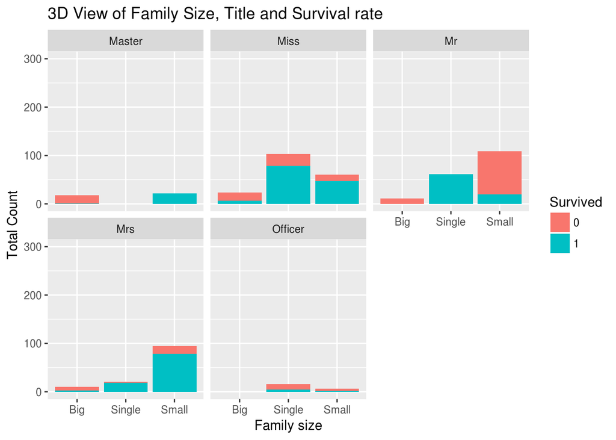

```r
ggplot(full.tt[1:891,], aes(x = FamilySized, fill = Survived)) +
  geom_bar() +
  facet_wrap( ~ title) +
  ggtitle("3D View of Family Size, Title and Survival rate") +
  xlab("Family size") +
  ylab("Total Count") +
  ylim(0,300) +
  labs(fill = "Survived")
```

* Survival rate for master in a big family is almost zero, even though the overall rate is reasonably high * Survival rate for Single people is highest almost across titles. There is a chance that they are with friends

Creating feature to indicate the number of passengers with the same ticket

```r
ticket.unique <- rep(0, nrow(full.tt))
tickets <- unique(full.tt$Ticket)

for(i in 1:length(tickets)){
  party.indexes <- which(full.tt$Ticket == tickets[i])

  for (k in 1:length(party.indexes)) {
    # replacing 0 with number of tickets with same ticket number for each ticket
    # this value will be same for similar ticket value
    ticket.unique[party.indexes[k]] <- length(party.indexes)
  }
}

full.tt$ticket.unique <- ticket.unique
```

Creating levels for the variable

```r
full.tt$ticket.size[full.tt$ticket.unique == 1] <- 'Single'
full.tt$ticket.size[full.tt$ticket.unique < 5 & full.tt$ticket.unique >= 2] <- 'Small'
full.tt$ticket.size[full.tt$ticket.unique >= 5] <- 'Big'
```

Survival rate for people for different ticket size

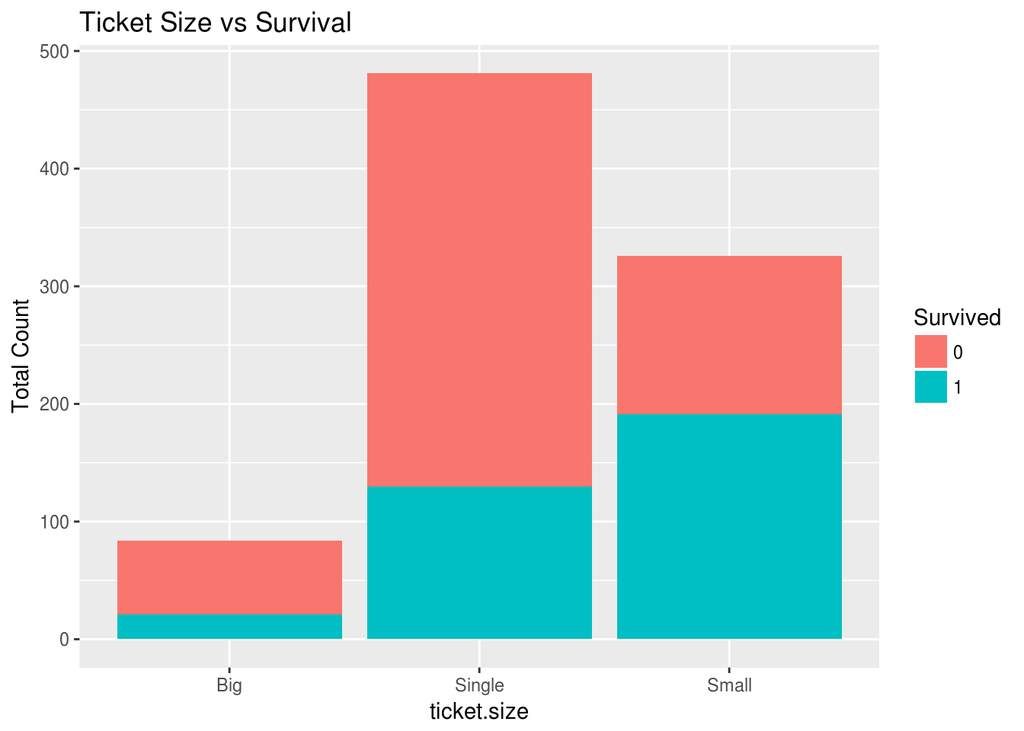

```r
ggplot(full.tt[1:891,], aes(x = ticket.size, fill = factor(Survived))) +
  geom_bar() +
  ggtitle("Ticket Size vs Survival")+
  xlab("ticket.size") +
  ylab("Total Count") +
  labs(fill = "Survived")
```

Adding a third dimension: title

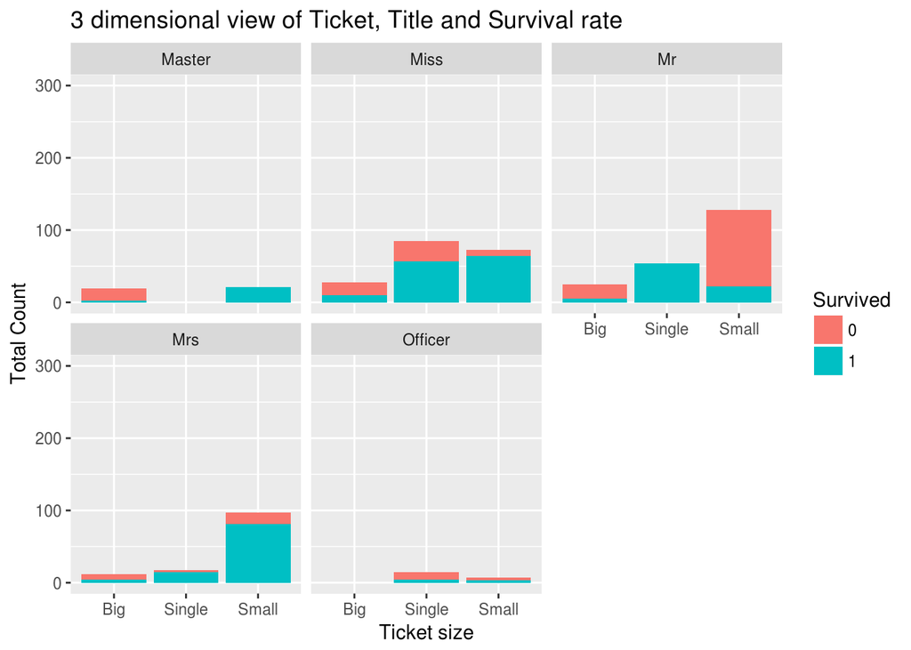

```r
ggplot(full.tt[1:891,], aes(x = ticket.size, fill = Survived)) +
  geom_bar() +
  facet_wrap( ~ title) +
  ggtitle("3 dimensional view of Ticket, Title and Survival rate") +
  xlab("Ticket size") +
  ylab("Total Count") +
  ylim(0,300) +
  labs(fill = "Survived")
```

Comparing ticket size and family size, we don’t see much difference between two. Maybe we can drop one of these out, that is contributing less.

### Embarked

Survival rate and where one gets on

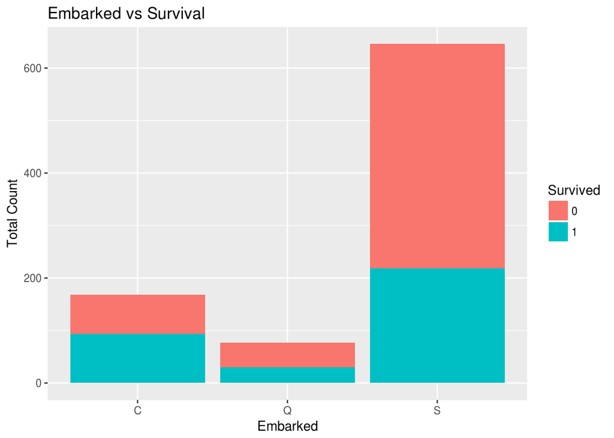

```r
ggplot(full.tt[1:891,], aes(x = Embarked, fill = factor(Survived))) +
  geom_bar() +
  ggtitle("Embarked vs Survival") +
  xlab("Embarked") +
  ylab("Total Count") +
  labs(fill = "Survived")
```

Further dividing the graph into class

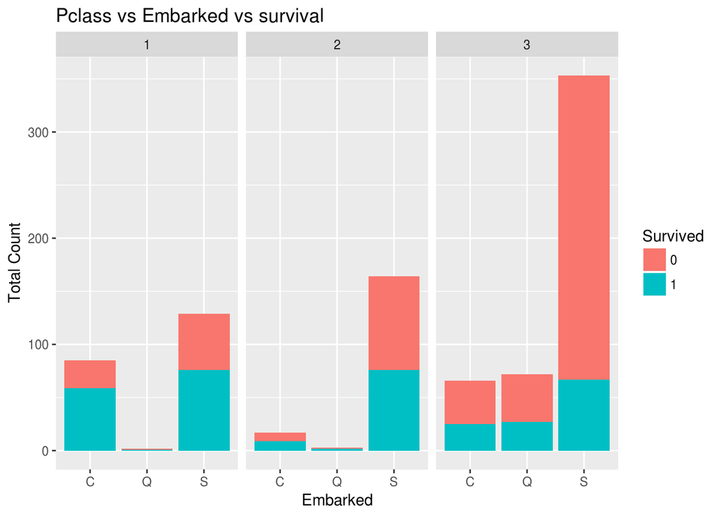

```r
ggplot(full.tt[1:891,], aes(x = Embarked, fill = Survived)) +
  geom_bar() +
  facet_wrap( ~ Pclass) +
  ggtitle("Pclass vs Embarked vs survival") +
  xlab("Embarked") +
  ylab("Total Count") +
  labs(fill = "Survived")
```

### About Variables

- Cabin has too many missing values, it doesn’t seem appropriate to use that
- We will use Title in place of Age
- Fare correlates with pclass, therefore we are not gonna use that as well

Converting these to factors

```r
full.tt$ticket.size <- as.factor(full.tt$ticket.size)
full.tt$title <- as.factor(full.tt$title)
```

### Final list of variables

1. Pclass
2. title
3. Sex
4. Embarked
5. FamilySized
6. ticket.size

Any redundant variable will be removed during the remaining analysis

## Dividing the data into training set and validation set

Filtering variables and observations and organizing data in proper format

```r
variable.list <- c("Pclass", "title","Sex","Embarked","FamilySized","ticket.size")

dataset <- full.tt[1:891, variable.list]
response <- as.factor(train.tt$Survived)
dataset$Survived <- as.factor(train.tt$Survived)
```

Creating validation set

```r
set.seed(500)
idx <- createDataPartition(dataset$Survived, times = 1, p = 0.8, list = F)
train.val <- dataset[idx,]
val <- dataset[-idx,]
```

Proportion of Survival rate in the original training data, current training and validation set

Original training set

```r
round(prop.table(table(train.tt$Survived)*100), digits = 2)
```

```
##
##    0    1
## 0.62 0.38
```

New training set

```r
round(prop.table(table(train.val$Survived)*100), digits = 2)
```

```
##
##    0    1
## 0.62 0.38
```

Validation set

```r
round(prop.table(table(val$Survived)*100), digits = 2)
```

```
##
##    0    1
## 0.62 0.38
```

## Modeling and Evaluation with Cross Validation

### Decision Tree

Random Forest has far better predictive power than a single tree but a single tree is very easy to use and illustrate

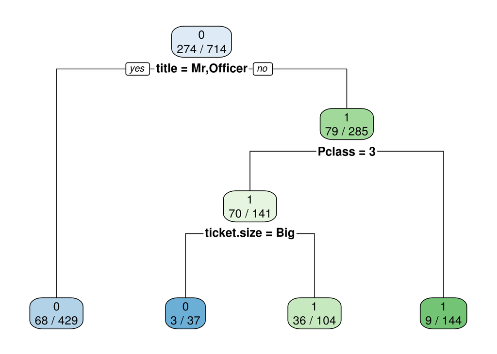

```r
set.seed(1234)
dt.model  <- rpart(Survived~., data=train.val, method = "class")
rpart.plot(dt.model, extra = 3, fallen.leaves = T)
```

The single tree is using only Title, pclass, and ticket.size and have omiited the rest

Making predictions on the training set

```r
pred.dt <- predict(dt.model, data=train.val, type = "class")
confusionMatrix(pred.dt, train.val$Survived)
```

```
## Confusion Matrix and Statistics
##
##           Reference
## Prediction   0   1
##          0 395  71
##          1  45 203
##
##                Accuracy : 0.8375
##                  95% CI : (0.8084, 0.8639)
##     No Information Rate : 0.6162
##     P-Value [Acc > NIR] : < 2e-16
##
##                   Kappa : 0.6502
##  Mcnemar's Test P-Value : 0.02028
##
##             Sensitivity : 0.8977
##             Specificity : 0.7409
##          Pos Pred Value : 0.8476
##          Neg Pred Value : 0.8185
##              Prevalence : 0.6162
##          Detection Rate : 0.5532
##    Detection Prevalence : 0.6527
##       Balanced Accuracy : 0.8193
##
##        'Positive' Class : 0
##
```

- Accuracy is 0.8375, which is not too bad given we have used only a single tree with just three features
- But there is a scope of overfitting, therefore we are gonna use 10 fold cross validation to determine complexity parameter

```r
set.seed(1234)
cv.10 <- createMultiFolds(train.val$Survived, k = 10, times = 10)

# Resampling technique
ctrl <- trainControl(method = "repeatedcv",
                     number = 10,
                     repeats = 10,
                     index = cv.10)

# Training the model
model.cdt <- train(x = train.val[,-7], y = train.val[,7],
                   method = "rpart",
                   tuneLength = 30,
                   trControl = ctrl)
```

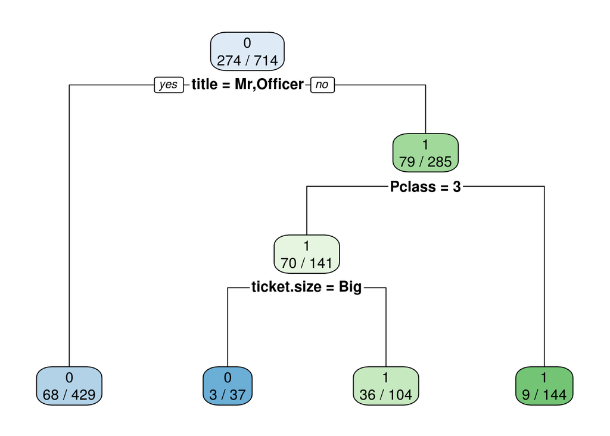

```r
rpart.plot(model.cdt$finalModel, extra = 3, fallen.leaves = T)
```

Acuuracy on the validation set

```r
pred.cdt <- predict(model.cdt$finalModel, newdata = val, type = "class")
confusionMatrix(pred.cdt, val$Survived)
```

```
## Confusion Matrix and Statistics
##
##           Reference
## Prediction  0  1
##          0 97 20
##          1 12 48
##
##                Accuracy : 0.8192
##                  95% CI : (0.7545, 0.8729)
##     No Information Rate : 0.6158
##     P-Value [Acc > NIR] : 3.784e-09
##
##                   Kappa : 0.6093
##  Mcnemar's Test P-Value : 0.2159
##
##             Sensitivity : 0.8899
##             Specificity : 0.7059
##          Pos Pred Value : 0.8291
##          Neg Pred Value : 0.8000
##              Prevalence : 0.6158
##          Detection Rate : 0.5480
##    Detection Prevalence : 0.6610
##       Balanced Accuracy : 0.7979
##
##        'Positive' Class : 0
##
```

Accuracy is 0.81

## Random Forest

```r
set.seed(1234)
(model.rf <- randomForest(x = train.val[,-7], y=train.val[,7],
                     importance = TRUE, ntree = 1000))
```

```
##
## Call:
##  randomForest(x = train.val[, -7], y = train.val[, 7], ntree = 1000,      importance = TRUE)
##                Type of random forest: classification
##                      Number of trees: 1000
## No. of variables tried at each split: 2
##
##         OOB estimate of  error rate: 17.09%
## Confusion matrix:
##     0   1 class.error
## 0 395  45   0.1022727
## 1  77 197   0.2810219
```

Variable importance plot

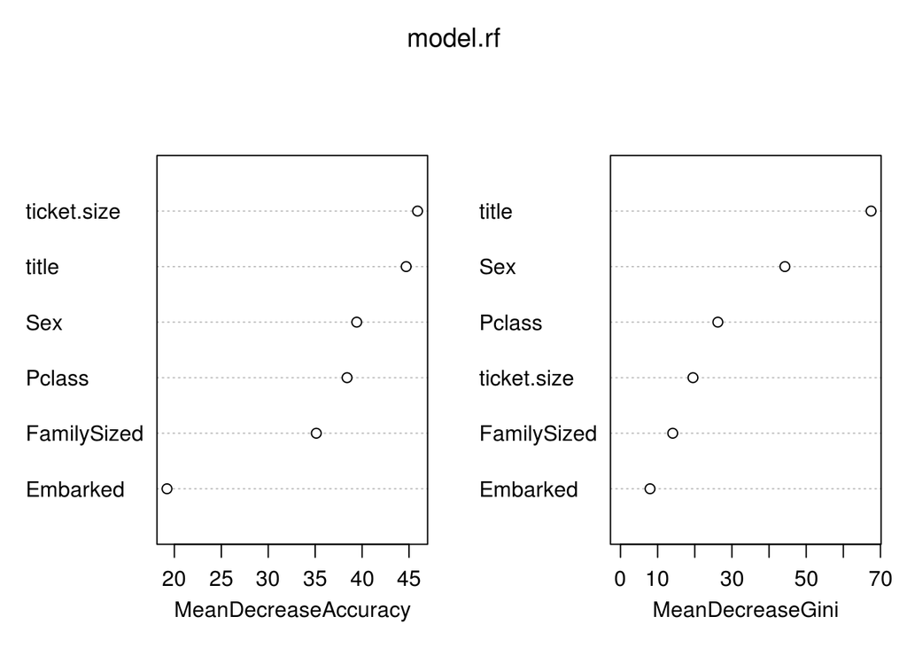

```r
varImpPlot(model.rf)
```

- Random Forest’s accuracy rate is .8291 which is 1% better than that of decison tree.

removing Embarked and Family Size and creating model again

```r
train.val1 <- train.val[,-4:-5]
val1 <- val[,-4:-5]

set.seed(1234)
(model.rf2 <- randomForest(x = train.val1[,-5], y = train.val1[,5],
                     importance = TRUE, ntree = 1000))
```

```
##
## Call:
##  randomForest(x = train.val1[, -5], y = train.val1[, 5], ntree = 1000,      importance = TRUE)
##                Type of random forest: classification
##                      Number of trees: 1000
## No. of variables tried at each split: 2
##
##         OOB estimate of  error rate: 15.97%
## Confusion matrix:
##     0   1 class.error
## 0 395  45   0.1022727
## 1  69 205   0.2518248
```

Checking Variable Importance

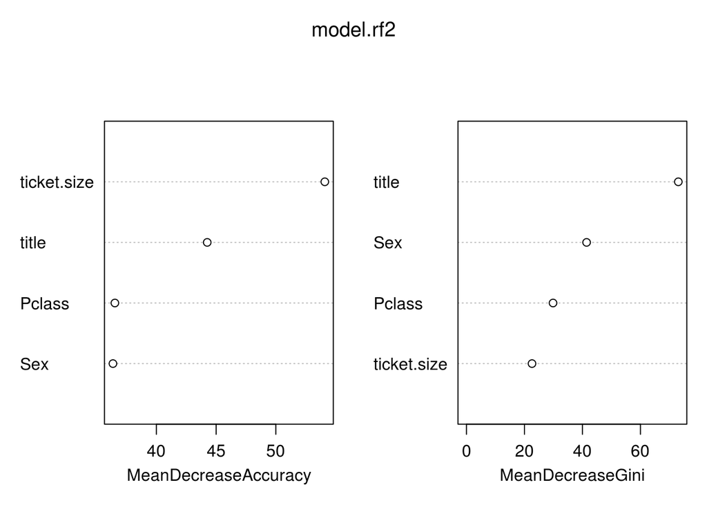

```r
varImpPlot(model.rf2)
```

Accuracy is 84.03%

Random Forest with Repeated Cross Validation

```r
set.seed(2348)
rcv10 <- createMultiFolds(train.val1[,5],
                           k = 10,
                           times = 10)

ctrl <- trainControl(method = "repeatedcv", number = 10, repeats = 10,
                      index = rcv10)

set.seed(1234)
(model.rf3 <- train(x = train.val1[,-5], y = train.val1[,5],
                   method = "rf", tuneLength = 3,
                   ntree = 1000,
                   trControl = ctrl))
```

```
## Random Forest
##
## 714 samples
##   4 predictors
##   2 classes: '0', '1'
##
## No pre-processing
## Resampling: Cross-Validated (10 fold, repeated 10 times)
## Summary of sample sizes: 642, 643, 642, 643, 643, 643, ...
## Resampling results across tuning parameters:
##
##   mtry  Accuracy   Kappa
##   2     0.8392390  0.6538299
##   3     0.8382551  0.6518851
##   4     0.8368466  0.6489636
##
## Accuracy was used to select the optimal model using  the largest value.
## The final value used for the model was mtry = 2.
```

Accurcay rate of .8393

Prediction on the validation dataset

```r
pred.rf <- predict(model.rf3, newdata = val1)

confusionMatrix(pred.rf, val1$Survived)
```

```
## Confusion Matrix and Statistics
##
##           Reference
## Prediction  0  1
##          0 97 20
##          1 12 48
##
##                Accuracy : 0.8192
##                  95% CI : (0.7545, 0.8729)
##     No Information Rate : 0.6158
##     P-Value [Acc > NIR] : 3.784e-09
##
##                   Kappa : 0.6093
##  Mcnemar's Test P-Value : 0.2159
##
##             Sensitivity : 0.8899
##             Specificity : 0.7059
##          Pos Pred Value : 0.8291
##          Neg Pred Value : 0.8000
##              Prevalence : 0.6158
##          Detection Rate : 0.5480
##    Detection Prevalence : 0.6610
##       Balanced Accuracy : 0.7979
##
##        'Positive' Class : 0
##
```

accuracy rate is 0.8192, which is lower than what we expected

## Linear Support Vector Classifier

Tuning the cost parameter

```r
set.seed(1274)
(linear.tune <- tune.svm(Survived~.,data=train.val1,
                        kernel = "linear",
                        cost=c(0.01,0.1,0.2,0.5,0.7,1,2,3,5,10,15,20,50,100)))
```

```
##
## Parameter tuning of 'svm':
##
## - sampling method: 10-fold cross validation
##
## - best parameters:
##  cost
##     3
##
## - best performance: 0.1736502
```

Best perforamnce is when cost is 3 and accuracy rate is 82.7

Best Linear model

```r
svm.linear <- linear.tune$best.model

# Predict Survival rate using validation data

pred.svm <- predict(svm.linear, newdata = val1, type="class")
confusionMatrix(pred.svm, val1$Survived)
```

```
## Confusion Matrix and Statistics
##
##           Reference
## Prediction  0  1
##          0 97 21
##          1 12 47
##
##                Accuracy : 0.8136
##                  95% CI : (0.7483, 0.8681)
##     No Information Rate : 0.6158
##     P-Value [Acc > NIR] : 1.058e-08
##
##                   Kappa : 0.5959
##  Mcnemar's Test P-Value : 0.1637
##
##             Sensitivity : 0.8899
##             Specificity : 0.6912
##          Pos Pred Value : 0.8220
##          Neg Pred Value : 0.7966
##              Prevalence : 0.6158
##          Detection Rate : 0.5480
##    Detection Prevalence : 0.6667
##       Balanced Accuracy : 0.7905
##
##        'Positive' Class : 0
##
```

Accuracy is 0.8136

## Radial Support Vector Machine

```r
set.seed(1274)
poly.tune <- tune.svm(Survived~., data = val1,
                      kernel = "radial",
                      gamma = seq(0.1,5))
summary(poly.tune)
```

```
##
## Parameter tuning of 'svm':
##
## - sampling method: 10-fold cross validation
##
## - best parameters:
##  gamma
##    1.1
##
## - best performance: 0.1862745
##
## - Detailed performance results:
##   gamma     error dispersion
## 1   0.1 0.2026144 0.10418865
## 2   1.1 0.1862745 0.09359321
## 3   2.1 0.1862745 0.08845692
## 4   3.1 0.2147059 0.10888943
## 5   4.1 0.2202614 0.11674796
```

```r
model.rsvm <- poly.tune$best.model

# Prediction on validation data
pred.rsvm <- predict(model.rsvm, newdata = val1)

confusionMatrix(pred.rsvm, val1$Survived)
```

```
## Confusion Matrix and Statistics
##
##           Reference
## Prediction   0   1
##          0 108  26
##          1   1  42
##
##                Accuracy : 0.8475
##                  95% CI : (0.7859, 0.897)
##     No Information Rate : 0.6158
##     P-Value [Acc > NIR] : 1.244e-11
##
##                   Kappa : 0.6537
##  Mcnemar's Test P-Value : 3.860e-06
##
##             Sensitivity : 0.9908
##             Specificity : 0.6176
##          Pos Pred Value : 0.8060
##          Neg Pred Value : 0.9767
##              Prevalence : 0.6158
##          Detection Rate : 0.6102
##    Detection Prevalence : 0.7571
##       Balanced Accuracy : 0.8042
##
##        'Positive' Class : 0
##
```

## Logistic Regression

Checking how the variables are coded

Survival rate

```r
contrasts(train.val1$Survived)
```

```
##   1
## 0 0
## 1 1
```

Pclass

```r
contrasts(train.val1$Pclass)
```

```
##   2 3
## 1 0 0
## 2 1 0
## 3 0 1
```

Building a logistic regression model

```r
model.logistic <- glm(Survived ~ .,
                      family = binomial(link=logit),
                      data = train.val1)
summary(model.logistic)
```

```
##
## Call:
## glm(formula = Survived ~ ., family = binomial(link = logit),
##     data = train.val1)
##
## Deviance Residuals:
##     Min       1Q   Median       3Q      Max
## -2.4187  -0.5944  -0.3937   0.5805   3.0414
##
## Coefficients:
##                   Estimate Std. Error z value Pr(>|z|)
## (Intercept)        16.8752   624.0921   0.027 0.978428
## Pclass2            -1.1968     0.3129  -3.824 0.000131 ***
## Pclass3            -2.1324     0.2721  -7.838 4.58e-15 ***
## titleMiss         -16.1021   624.0921  -0.026 0.979416
## titleMr            -3.7422     0.5216  -7.175 7.24e-13 ***
## titleMrs          -16.0186   624.0921  -0.026 0.979523
## titleOfficer       -4.3752     0.8595  -5.090 3.58e-07 ***
## Sexmale           -15.6157   624.0919  -0.025 0.980038
## ticket.sizeSingle   2.0968     0.4082   5.137 2.79e-07 ***
## ticket.sizeSmall    2.0356     0.3870   5.260 1.44e-07 ***
## ---
## Signif. codes:  0 '***' 0.001 '**' 0.01 '*' 0.05 '.' 0.1 ' ' 1
##
## (Dispersion parameter for binomial family taken to be 1)
##
##     Null deviance: 950.86  on 713  degrees of freedom
## Residual deviance: 589.82  on 704  degrees of freedom
## AIC: 609.82
##
## Number of Fisher Scoring iterations: 13
```

checking the confidence interval

```r
confint(model.logistic)
```

[output not shown]

[output cut: 30 more lines]

[output not shown]

```
##                        2.5 %     97.5 %
## (Intercept)       -80.363813         NA
## Pclass2            -1.821261 -0.5924824
## Pclass3            -2.676712 -1.6082641
## titleMiss                 NA 81.1580568
## titleMr            -4.806899 -2.7544131
## titleMrs                  NA 81.2072009
## titleOfficer       -6.200669 -2.7777761
## Sexmale                   NA 81.9299127
## ticket.sizeSingle   1.318753  2.9224495
## ticket.sizeSmall    1.294852  2.8160324
```

Making predictions on training data

```r
probpred.log <- predict(model.logistic, data=train.val1,
                       type =  "response")
table(train.val1$Survived, probpred.log > 0.5)
```

```
##
##     FALSE TRUE
##   0   395   45
##   1    70  204
```

```r
(395+204)/(395+204+70+45)
```

```
## [1] 0.8389356
```

83% Accuracy with training dataset

Predictions on test dataset

```r
valprobpred.log <- predict(model.logistic,
                           newdata = val1,
                           type =  "response")
table(val1$Survived,valprobpred.log > 0.5)
```

```
##
##     FALSE TRUE
##   0    97   12
##   1    21   47
```

```r
(97+47)/(97+12+21+47)
```

```
## [1] 0.8135593
```

81.3% accuracy on validation set